Barakar Valley Power Distribution Limited · Neamatpur 33/11 kV

# Storm Restoration After-Action Report

August Monsoon Depression

| Event period | 11 August 2026 09:15 to 11 August 2026 21:30 |
| --- | --- |
| Consumers served | 28,400 |
| Records reviewed | 42 across six record sets |

This report keeps two kinds of statement apart. **Observed** statements are traceable to a numbered record and carry that record in square brackets. **Assessed** statements are the response team's judgement and carry no record because none supports them. Where the records cannot answer a question, the report says so rather than estimating. A citation's prefix names the record set it came from: **TEL** network telemetry, **DMG** a damage record, **CRW** a crew record, **COM** a consumer contact, **FLD** a crew's report from site, **WEA** a weather reading.

## Executive Summary

[output not shown]

## 1. Event Overview

### Observed

August Monsoon Depression began affecting the Neamatpur 33/11 kV network at 11:05 on 11 August 2026, when the first outages were recorded on feeder 11 kV BRK-03 [TEL-0001]. Consumers without supply peaked at 9,200, which is 32.4 per cent of the 28,400 consumers served by the substation, at 12:30 on 11 August [TEL-0003]. Full restoration took 10 hours 10 minutes from the first recorded outage to the final consumer restored at 21:15 on 11 August [TEL-0001, TEL-0009].

### Assessed

The response is judged to have met its restoration objective, with no service interruption extending beyond the operating standard [assessed].

## 2. Timeline of Events

### Observed

- **11 August, 09:00–10:00** — IMD Kolkata issues a heavy rainfall warning for Paschim Bardhaman as a monsoon depression tracks across Gangetic West Bengal. [WEA-0001]
- **11 August, 10:00–11:00** — Rainfall of 42 mm in one hour recorded at the Neamatpur substation gauge. [WEA-0002]
- **11 August, 11:00–12:00** — BRK-03 tripped on earth fault after tree contact in the Nunia canal corridor. line gang of 6 from Neamatpur mobilised to 11 kV BRK-03. [TEL-0001, CRW-0001, DMG-0001, FLD-0001, CRW-0002, FLD-0002, TEL-0002, CRW-0003, DMG-0002]
- **11 August, 12:00–13:00** — Conductor down at low height beside the road. MHS-07 out after a distribution transformer failed at Mohishila. [FLD-0003, TEL-0003, CRW-0004, DMG-0003]
- **11 August, 13:00–14:00** — Peak consumers without supply confirmed at 9,200 across three feeders. Gusts to 58 km/h recorded at the Sitarampur monitoring mast. [TEL-0004, WEA-0003, CRW-0005]
- **11 August, 14:00–15:00** — 3 insulators at Kulti section poles 17 to 19 confirmed damaged (raised by a crew). Three insulators found cracked while replacing the tilted poles. [DMG-0004, FLD-0004, TEL-0005]
- **11 August, 15:00–16:00** — 2 cross arms at Mohishila Colony confirmed damaged (raised by a consumer). Pole reported by a consumer during the April event inspected. [DMG-0005, FLD-0005]
- **11 August, 16:00–17:00** — MHS-07 restored after transformer replacement at Mohishila. [TEL-0006]
- **11 August, 17:00–18:00** — Rain eases to light showers. [WEA-0004]
- **11 August, 18:00–19:00** — KLT-02 restored to the Kulti trunk. [TEL-0007]
- **11 August, 20:00–21:00** — Remaining outages are individual service connections on the Kulti laterals. All conductor-down sites cleared and released for normal operation. [TEL-0008, FLD-0006]
- **11 August, 21:00–22:00** — Final consumer restored. Outage management system link remained available for the whole event and consumer counts were recorded continuously. [TEL-0009, TEL-0010]

## 3. Damage Assessment

### Observed

- Confirmed damage across the substation area: 3 conductor spans, 3 insulators, 2 poles, 2 cross arms, 1 transformer [DMG-0001, DMG-0002, DMG-0003, DMG-0004, DMG-0005].
- 5 damage records were raised: 2 by network telemetry, 2 by a consumer contact, 1 by a crew on site [DMG-0001, DMG-0002, DMG-0003, DMG-0004, DMG-0005].

### Assessed

The damage profile is consistent with wind and tree contact rather than with any underlying asset condition, and no pattern of premature failure is apparent [assessed].

## 4. Crew Mobilisation

### Observed

6 crews totalling 31 field personnel were mobilised for the event [CRW-0001, CRW-0002]. 1 mutual-aid crew totalling 6 personnel was requested from Durgapur [CRW-0006]. Crews worked approximately 118 personnel-hours on the event. This figure covers 5 of 6 crews; the remaining 1 has incomplete records and is excluded [CRW-0001, CRW-0002, CRW-0003].

### Assessed

Mutual aid was requested at an appropriate point in the event, and earlier escalation would not have materially shortened the restoration [assessed].

### What the records do not show

Crew CRW-0006 (6 personnel from Durgapur) has no mobilisation time in the records, so its hours cannot be computed and are excluded from the personnel-hours total. [no record].

## 5. Restoration Performance

### Observed

- 50 per cent of affected consumers were restored within 3 hours 50 minutes of peak outage, by 16:20 on 11 August when 3,460 consumers remained without supply [TEL-0003, TEL-0006].
- 90 per cent of affected consumers were restored within 7 hours 40 minutes of peak outage, by 20:10 on 11 August when 380 consumers remained without supply [TEL-0003, TEL-0008].
- 9 consumer counts were recorded across the event, from 11:05 on 11 August to 21:15 on 11 August [TEL-0001, TEL-0009].
- 1 access constraint were recorded during restoration, each one holding work on a section until it cleared [FLD-0002].

### Assessed

Restoration sequencing prioritised the highest-count feeders correctly, and the resulting curve is consistent with the damage sustained and the access available [assessed].

## 6. Consumer Communications

### Observed

The first consumer notification was issued at 11:43 on 11 August, 38 minutes after the first recorded outage [TEL-0001, COM-0002]. 6 notifications were issued to consumers across 4 channels (IVR, SMS, WhatsApp, web), reaching 33,460 recipients in total [COM-0002, COM-0003, COM-0007]. 319 consumer contacts were received across 4 channels (SMS, WhatsApp, call centre, email) in 6 batches [COM-0001, COM-0004, COM-0005]. 319 of those contacts were resolved, averaging 4 hours 28 minutes from contact to resolution, all inside the 12-hour target [COM-0001, COM-0004, COM-0005].

### Assessed

Message cadence was appropriate to the restoration profile, and consumers received revised estimates at the points where the estimates materially changed [assessed].

### What the records do not show

4 messages (COM-0004, COM-0006, COM-0009, COM-0011) carry no reference to a telemetry or field record, so they cannot be corroborated against the rest of the event. [no record].

## 7. Restoration Curve

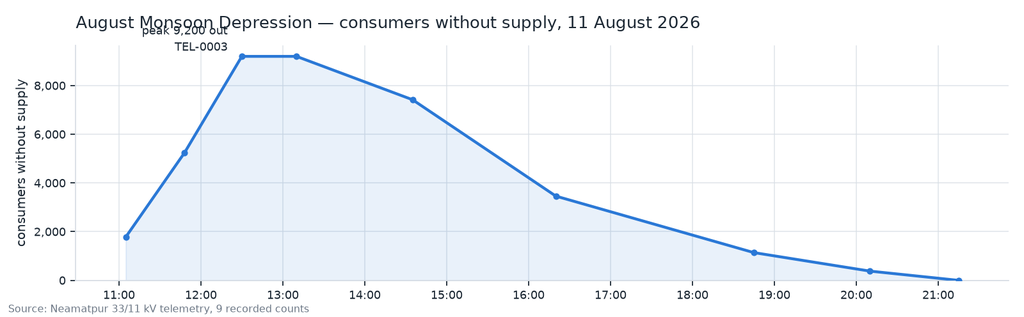

*Consumers without supply over the course of August Monsoon Depression, peaking at 9,200 at 12:30 on 11 August 2026 [TEL-0003].*

## 8. Consumer Contacts

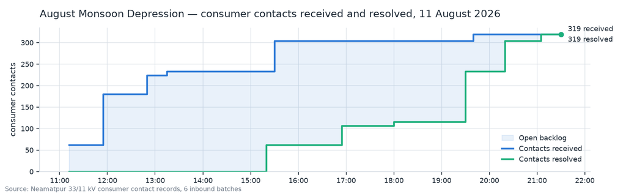

*Consumer contacts received and resolved over the course of August Monsoon Depression, 319 received in total. Every contact was resolved before the event closed.*

## 9. Lessons Learned

### Carried forward from previous events

| Item | Raised in | Owner | Status | Note |
| --- | --- | --- | --- | --- |
| LL-A1: Mutual-aid gang mobilisation times are not captured | storm-a | Distribution Operations, Neamatpur Section | Open | A mutual-aid gang from the Durgapur circle worked this event and again carries no mobilisation time. [storm-b/CRW-0006] |
| LL-A2: Time to first consumer notification exceeded the two-hour target | storm-a | Consumer Services Wing | Closed in storm-b | First consumer notification was issued 38 minutes after the first recorded outage, inside the two-hour target. [storm-b/TEL-0001, storm-b/COM-0002] |
| LL-A3: Outage management system link was lost with no fallback capture | storm-a | SCADA and IT Wing | Open | The link held for this event, so the gap did not recur, but the manual fallback capture procedure remains undeveloped. [storm-b/TEL-0010] |
| LL-A4: A consumer-reported pole was never inspected | storm-a | Distribution Operations, Neamatpur Section | Closed in storm-b | The Mohishila Bazaar pole was inspected during this event. The tree trunk has been removed and the pole is sound. [storm-b/FLD-0005] |

### Raised by this event

LL-B1 — Tree contact in the Nunia canal corridor initiated the event. The first outage originated from branch contact in the Nunia canal corridor, which the section engineer records as last cleared in 2023. Restringing could not start until a tree-cutting gang had opened the corridor. Owner: Line Clearance Wing. [DMG-0001, FLD-0002].